# Assignment 3

## Submit as an HTML file

Print your Emory ID below

```python
print('2509241')
```

```
2509241
```

Import the numpy and matplotlib packages

```python
import numpy as np
import matplotlib.pyplot as plt
```

(a) Compute a formula:

$V=P\left(1+{\frac {r}{n}}\right)^{nt}$

Calculate $V$ when:

- $P = 2100 $
- $r = 0.034$
- $n = 4$
- $t = 7$

To get full points:

- First define each of these variables
- Write the formula above

```python
# Note (if you're interested in the context)
# V = Accumulated value of investment
# P =  Principal (the amount deposited)
# r =  Quarterly interest rate
# n = Number of quarters in a year
# t = number of years

p = 2100
r = 0.034
n = 4
t = 7
v = p*((1+(r/n))**(n*t))
print(v)
```

```
2661.6108980682593
```

(b) Composite operations on arrays

- Define $r = 0.04"
- Define two arrays $A$ and $T$ using "np.array()", assigning the following values $ a = \begin{pmatrix} a_1 \\ a_2 \\ a_3 \end{pmatrix} = \begin{pmatrix} 20 \\ 30 \\ 15 \end{pmatrix}, \qquad t = \begin{pmatrix} t_1 \\ t_2 \\ t_3 \end{pmatrix} = \begin{pmatrix} 0 \\ 1 \\ 2 \end{pmatrix} $
- Use element-by-element vector operations to compute a new array $M$ of length 3: $ M = \begin{pmatrix} a_1 / (1+r)^{t_0} \\ a_2 / (1+r)^{t_1} \\ a_3 / (1+r)^{t_2} \end{pmatrix} $
- Compute the sum of the values of $M$ using "M.sum()" Note: I am using subscripts to denote the individual elements of $a$ and $t$.
- In the code just enter the values of $a$ and $t$.
- To get full points you must do all of the above tasks

```python
r = 0.04
vec_a  = np.array([20,30,15])
vec_t  = np.array([0,1,2])
vec_m = (vec_a/(1+r)**vec_t)
print(vec_m)
vec_m.sum()
```

```
[20.         28.84615385 13.8683432 ]
```

```
62.71449704142012
```

(c) Plot a normal random variable

To get full points:

- Set a seed using "np.random.seed()"
- Create the random variable with the following parameters
- mean = 5, standard deviation = 2, and size = 1000
- Create a histogram
- Label the axes

[output not shown]

[output cut: 112 more lines]

[output not shown]

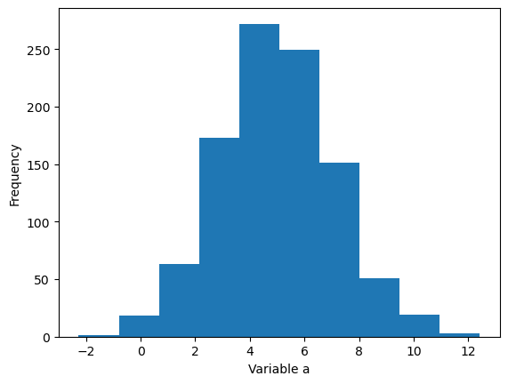

```python
np.random.seed(10245)
random_var = np.random.normal(loc=5, scale=2, size=1000)
print(random_var)
plt.hist(x = random_var)
plt.xlabel("Variable a")
plt.ylabel("Frequency")
```

(d) Checking whether word is part of list

- Define a variable "fruit" with the value "apple"
- Define a list of fruits with the values list_fruits = ["banana","orange","apple"]
- Write an expression to test whether "fruit" is contained in "list_fruits"

Hint: Use the "in" command. The final output should be True/False.

To get full points run all of the above commands

```python
fruit = "apple"
list_fruits = ['banana', 'orange', 'apple']
print( fruit in list_fruits)
```

```
True
```

(e) Classifying a variable

- Define a new variable "year" an assign it "2008"
- Write an if/else statement that does the following
  - print("Year 2000 or earlier") if the year is less than or equal to 2000.
  - print("Between 2001 and 2005") if the year is between 2001 and 2005.
  - print("Year 2006 or later") if the year is after 2005.

To get full points you must do all of the above instructions

```python
year = 2008
if year <= 2000:
    print("Year 2000 or ealier")
if (year >= 2001)  &  (year <= 2005):
    print("Between 2001 and 2005")
if year > 2006:
    print("Year 2006 or later")
```

```
Year 2006 or later
```